# Linear Models with the rstanarm R Package

April 13, 2020

## Difficulty of Analytical Bayesian Inference

- Bayes Rule for an unknown parameter (vector) \(\boldsymbol{\theta}\) conditional on known data (vector) \(\mathbf{y}\) can be written as \[f\left(\boldsymbol{\theta} \mid \mathbf{y}\right) = \frac{f\left(\boldsymbol{\theta}\right) f\left(\mathbf{y} \mid \boldsymbol{\theta}\right)} {f\left(\mathbf{y}\right)} = \frac{f\left(\boldsymbol{\theta}\right) f\left(\mathbf{y} \mid \boldsymbol{\theta}\right)} {\int_{-\infty}^\infty \int_{-\infty}^\infty \dots \int_{-\infty}^\infty f\left(\boldsymbol{\theta}\right) f\left(\mathbf{y} \mid \boldsymbol{\theta}\right) d\theta_1 d\theta_2 \dots d\theta_K}\]
- To obtain the denominator of Bayes Rule, you would need to do an integral
- The [Risch Algorithm](https://en.wikipedia.org/wiki/Risch_algorithm) tells you if an integral has an elementary form (rare)
- In most cases, we can’t write the denominator of Bayes Rule in a useful form
- But we can draw from a distribution whose PDF is characterized by the numerator of Bayes Rule without knowing the denominator

## Four Ways to Execute Bayes Rule

1. Draw from the prior predictive distribution and keep realizations of the parameters iff the realization of the outcome matches the observed data
   - Very intuitive what is happening but is only possible with discrete outcomes and only feasible with few observations and parameters
2. Numerically integrate the numerator of Bayes Rule over the parameter(s)
   - Most similar to what we did in the discrete case but is only feasible when there are few parameters and can be inaccurate even with only one
3. Analytically integrate the numerator of Bayes Rule over the parameter(s)
   - Makes incremental Bayesian learning obvious but is only possible in simple models when the distribution of the outcome is in the exponential family
4. Use MCMC to sample from the posterior distribution
   - Stan works for any posterior PDF that is differentiable w.r.t. the parameters

## Comparing Stan to Ancient MCMC Samplers

- Like M-H, only requires user to specify numerator of Bayes Rule
- Like M-H but unlike Gibbs sampling, proposals are joint
- Unlike M-H but like Gibbs sampling, proposals always accepted
- Unlike M-H but like Gibbs sampling, tuning of proposals is (often) not required
- Unlike both M-H and Gibbs sampling, the effective sample size is typically 25% to 125% of the nominal number of draws from the posterior distribution because \(\rho_1\) can be negative in \(n_{eff} = \frac{S}{1 + 2\sum_{k=1}^\infty \rho_k}\)
- Unlike both M-H and Gibbs sampling, Stan produces warning messages when things are not going swimmingly. Do not ignore these!
- Unlike BUGS, Stan does not permit discrete unknowns but even BUGS has difficulty drawing discrete unknowns with a sufficient amount of efficiency

## Linear Model

The prior predictive distribution for a linear model proceeds like \[\alpha \thicksim ??? \\ \boldsymbol{\beta} \thicksim ??? \\ \forall n: \mu_n = \alpha + \sum_{k = 1}^K \beta_k x_{nk} \\ \sigma \thicksim ??? \\ \forall n: \epsilon_n \thicksim \mathcal{N}\left(0, \sigma\right) \\ \forall n: y_n = \mu_n + \epsilon_n\] where `???` indicates the parameter to the left is drawn from a distribution that is up to you.

## Hibbs Bread Model for Presidential Vote %

- What is the relationship between growth and incumbent party vote share?

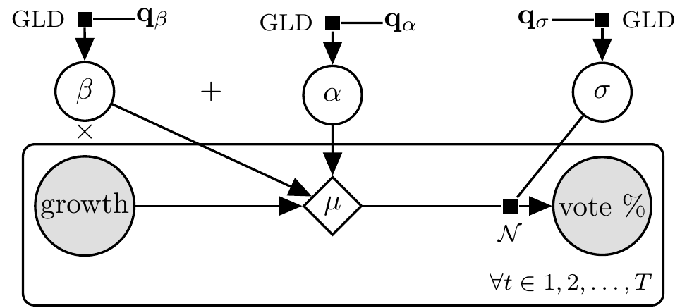

  Hibbs Model

## Breakout Rooms

Use R to draw \(S = 10000\) times (using `replicate`) from the prior predictive distribution of the Hibbs model with reasonable GLD priors, which require

```r
rstan::expose_stan_functions(file.path("..", "Week2", "quantile_functions.stan")) # GLD_icdf
source(file.path("..", "Week2", "GLD_helpers.R")) # GLD_solver and GLD_solver_bounded
ROOT <- "https://raw.githubusercontent.com/avehtari/ROS-Examples/master/"
hibbs <- readr::read_delim(paste0(ROOT, "ElectionsEconomy/data/hibbs.dat"), delim = " ")
hibbs$growth <- hibbs$growth - mean(hibbs$growth) # centering
y_ <- t(replicate(10000, {
  # fill in this part
}))
```

## Answer: Hyperparameters of GLD Priors

```r
a_s_alpha <- GLD_solver_bounded(bounds = c(0, 100), median = 52, IQR = 4)
a_s_beta <- GLD_solver(lower_quartile = -2, median = 0, upper_quartile = 3,
                       other_quantile = 6.5, alpha = 0.9)
a_s_sigma <- GLD_solver(lower_quartile = 2.5, median = 4, upper_quartile = 6,
                        other_quantile = 0, alpha = 0)
```

## Answer: Prior Predictive Distribution

```r
vote_ <- t(replicate(10000, {
  alpha_ <- GLD_icdf(runif(1), median = 52, IQR = 4,
                    asymmetry = a_s_alpha[1], steepness = a_s_alpha[2])
  beta_ <- GLD_rng(median = 0, IQR = 3 - -2, # same as passing runif(1) to GLD_icdf
                   asymmetry = a_s_beta[1], steepness = a_s_beta[2])
  mu_ <- alpha_ + beta_ * hibbs$growth
  sigma_ <- GLD_rng(median = 4, IQR = 6 - 2.5,
                    asymmetry = a_s_sigma[1], steepness = a_s_sigma[2])
  epsilon_ <- rnorm(n = length(mu_), mean = 0, sd = sigma_)
  y_ <- mu_ + epsilon_ # y_ has a normal distribution with expectation mu_
  y_
}))
colnames(vote_) <- hibbs$year
```

## Checking the Prior Predictive Distribution

```r
summary(vote_) # a little too wide
```

```
##       1952              1956               1960              1964             1968
##  Min.   :-0.4549   Min.   : -0.4877   Min.   : -3.886   Min.   :-18.87   Min.   : 10.32
##  1st Qu.:48.8175   1st Qu.: 48.5606   1st Qu.: 46.488   1st Qu.: 46.76   1st Qu.: 48.45
##  Median :52.5403   Median : 52.6831   Median : 51.253   Median : 52.87   Median : 52.73
##  Mean   :52.5904   Mean   : 53.0959   Mean   : 50.760   Mean   : 54.50   Mean   : 53.21
##  3rd Qu.:56.3395   3rd Qu.: 57.2168   3rd Qu.: 55.512   3rd Qu.: 60.46   3rd Qu.: 57.61
##  Max.   :95.5229   Max.   :105.7294   Max.   :109.594   Max.   :201.82   Max.   :119.28
##       1972             1976              1980             1984             1988
##  Min.   : -7.34   Min.   :  2.184   Min.   :-99.92   Min.   :-18.62   Min.   :-0.8681
##  1st Qu.: 47.82   1st Qu.: 47.038   1st Qu.: 43.52   1st Qu.: 47.41   1st Qu.:48.7976
##  Median : 53.00   Median : 51.339   Median : 51.32   Median : 52.88   Median :52.3899
##  Mean   : 53.98   Mean   : 51.136   Mean   : 49.51   Mean   : 54.25   Mean   :52.4509
##  3rd Qu.: 59.15   3rd Qu.: 55.372   3rd Qu.: 57.08   3rd Qu.: 59.78   3rd Qu.:56.0688
##  Max.   :172.22   Max.   :120.397   Max.   :100.87   Max.   :168.11   Max.   :89.5535
##       1992             1996              2000              2004              2008
##  Min.   :-25.07   Min.   :  1.563   Min.   :  5.036   Min.   :  1.347   Min.   :-49.01
##  1st Qu.: 45.40   1st Qu.: 46.941   1st Qu.: 48.667   1st Qu.: 48.240   1st Qu.: 44.70
##  Median : 51.08   Median : 51.387   Median : 52.458   Median : 51.844   Median : 51.25
##  Mean   : 50.27   Mean   : 51.064   Mean   : 52.477   Mean   : 51.890   Mean   : 50.05
##  3rd Qu.: 55.92   3rd Qu.: 55.350   3rd Qu.: 56.207   3rd Qu.: 55.403   3rd Qu.: 56.36
##  Max.   :123.51   Max.   :129.069   Max.   :117.500   Max.   :112.482   Max.   :106.71
##       2012
##  Min.   : -2.40
##  1st Qu.: 46.72
##  Median : 51.34
##  Mean   : 51.03
##  3rd Qu.: 55.49
##  Max.   :131.60
```

## Tthe `stan_glm` Function in the rstanarm Package

```r
options(mc.cores = parallel::detectCores()) # use all the cores on your computer
post <- stan_glm(inc.party.vote ~ growth, data = hibbs, family = gaussian,
                 prior_intercept = normal(location = 52, scale = 2, autoscale = FALSE),
                 prior = normal(location = 2.5, scale = 1, autoscale = FALSE),
                 prior_aux = exponential(rate = 0.25, autoscale = FALSE)) # expectation of 4
```

```r
post
```

```
...
## ------
##             Median MAD_SD
## (Intercept) 52.1    0.8
## growth       2.9    0.6
##
## Auxiliary parameter(s):
##       Median MAD_SD
## sigma 3.8    0.7
##
## Sample avg. posterior predictive distribution of y:
##          Median MAD_SD
## mean_PPD 52.0    1.2
##
## ------
## * For help interpreting the printed output see ?print.stanreg
## * For info on the priors used see ?prior_summary.stanreg
...
```

## Plotting the Marginal Posterior Densities

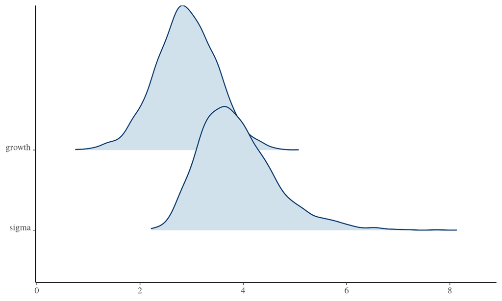

```r
plot(post, plotfun = "areas_ridges", pars = c("growth", "sigma")) # exclude the intercept
```

## Credible Intervals and \(R^2\)

```r
round(posterior_interval(post, prob = 0.8), digits = 2)
```

```
##               10%   90%
## (Intercept) 50.97 53.15
## growth       2.14  3.64
## sigma        3.05  4.86
```

```r
summary(bayes_R2(post))
```

```
##    Min. 1st Qu.  Median    Mean 3rd Qu.    Max.
## 0.04475 0.46900 0.55040 0.52872 0.61218 0.70365
```

## Sampling Distribution of OLS vs. Posterior Kernel

```
functions { /* saved as OLS_rng.stan*/
  matrix OLS_rng(int S, real alpha, real beta,
                 real sigma, vector x) {
    matrix[S, 3] out; int N = rows(x);
    vector[N] x_ = x - mean(x);
    vector[N] mu = alpha + beta * x_;
    real SSX = sum(square(x_)); int Nm2 = N - 2;
    for (s in 1:S) {
      vector[N] y = to_vector(normal_rng(mu, sigma));
      real a = mean(y);
      real b = sum(y .* x_) / SSX;
      vector[N] residuals = y - (a + b * x_);
      real s2_hat = sum(square(residuals)) / Nm2;
      out[s, ] = [a, b, s2_hat];
    }
    return out;
  }
}
```

```
functions { /* saved as lm_kernel.stan*/
  real lm_kernel(real alpha, real beta, real tau,
                 vector y, vector x) {
    int N = rows(x);
    vector[N] x_ = x - mean(x);
    vector[N] mu = alpha + beta * x_;



    // alpha and beta have improper priors ...
    // ... so they add nothing to the log-kernel
    //       vvv inv_sqrt(tau) = 1 / sqrt(tau)
    real sigma = inv_sqrt(tau);
    return -log(tau) // Jeffreys prior on tau
           + normal_lpdf(y | mu, sigma);
           // ^^^ log-likelihood of parameters
  }
}
```

## Normal Distribution of the True Test Statistic

```r
rstan::expose_stan_functions("OLS_rng.stan"); x <- lfactorial(0:16); alpha <- 0
beta <- 0.5; sigma <- 10; OLS <- OLS_rng(S = 10 ^ 5, alpha, beta, sigma, x); colMeans(OLS)
```

```
## [1]  -0.002718179   0.500792448 100.012222281
```

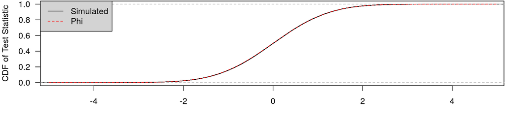

```r
se <- sqrt(sigma ^ 2 / sum( (x - mean(x)) ^ 2 )) # true standard error of estimated slope
plot(ecdf((OLS[ , 2] - beta) / se), main = "", xlab = "", ylab = "CDF of Test Statistic")
curve(pnorm(z), from = -5, to = 5, lty = 2, col = 2, add = TRUE, xname = "z")
legend("topleft", legend = c("Simulated", "Phi"), col = 1:2, lty = 1:2, bg = "lightgrey")
```

## Student t Distribution of Estimated Test Statistic

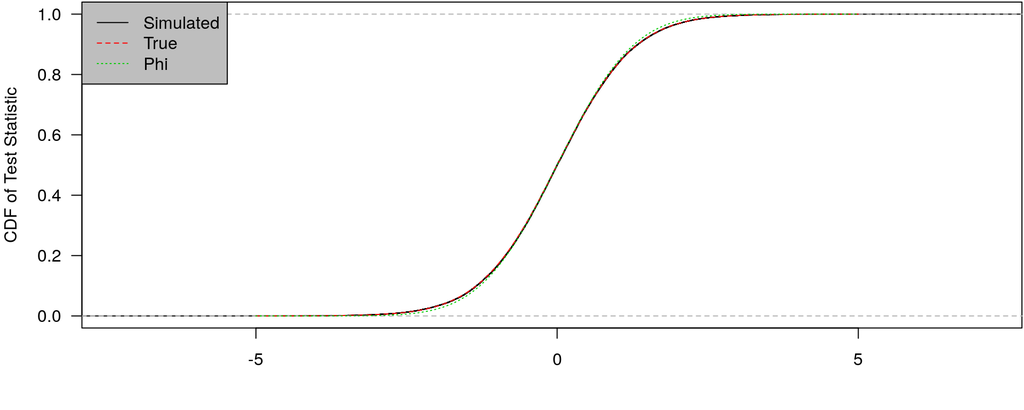

```r
se_hat <- sqrt(OLS[ , 3] / sum( (x - mean(x)) ^ 2 )) # estimated standard error of estimate
plot(ecdf((OLS[ , 2] - beta) / se_hat), main = "", xlab = "", ylab =  "CDF of Test Statistic")
curve(pt(z, df = 17 - 2), from = -5, to = 5, lty = 2, col = 2, add = TRUE, xname = "z")
curve(pnorm(z), from = -5, to = 5, lty = 3, col = 3, add = TRUE, xname = "z")
legend("topleft", legend = c("Simulated", "True", "Phi"), col = 1:3, lty = 1:3, bg = "grey")
```

## Power of the Test that \(\beta = 0\) against \(\beta > 0\)

```r
round(x, digits = 4)
```

```
##  [1]  0.0000  0.0000  0.6931  1.7918  3.1781  4.7875  6.5793  8.5252 10.6046 12.8018
## [11] 15.1044 17.5023 19.9872 22.5522 25.1912 27.8993 30.6719
```

```r
mean( (OLS[ , 2] - 0) / se_hat > qt(0.95, df = 17 - 2) )
```

```
## [1] 0.62395
```

In other words, for THESE \(17\) values of \(x\), we EXPECT (over \(Y\)) to reject the false null hypothesis that \(\beta = 0\) in favor of the alternative hypothesis that \(\beta > 0\) at the 5% level with probability \(0.624\) when the true value of \(\beta\) is \(\frac{1}{2}\).

- What good is this PRE-DATA (on \(y_1, y_2, \dots, y_{17}\)) statement?
- But in this case the posterior distribution is the same as the estimated sampling distribution of the OLS estimator across datasets

## Breakout Rooms: IQ of Three Year Olds

- All examples from the reading (plus more) are available at https://github.com/avehtari/RAOS-Examples
- At 36 months, kids were given an IQ test
- Suppose the conditional expectation is a linear function of whether its mother graduated high school and the IQ of the mother
- In breakout rooms, draw from the prior predictive distribution of the outcome using independent normal priors on the intercept and coefficients and an exponential prior on \(\sigma\)

```r
data(kidiq, package = "rstanarm")
colnames(kidiq) # remember to center
```

```
## [1] "kid_score" "mom_hs"    "mom_iq"    "mom_age"
```

## Answer

```r
kid_score <- with(kidiq, t(replicate(10000, {
  alpha_ <- rnorm(1, mean = 100, sd = 15)
  beta_hs_ <- rnorm(1, mean = 0, sd = 2.5)
  beta_iq_ <- rnorm(1, mean = 0, sd = 2.5)
  mu_ <- alpha_ + beta_hs_ * (mom_hs - mean(mom_hs)) + beta_iq_ * (mom_iq - mean(mom_iq))

  sigma_ <- rexp(1, rate = 1 / 15)
  epsilon_ <- rnorm(n = length(mu_), mean = 0, sd = sigma_)
  mu_ + epsilon_
})))
summary(kid_score[ , 1]) # predictive distribution for first 3 year old (too wide)
```

```
##    Min. 1st Qu.  Median    Mean 3rd Qu.    Max.
## -211.15   60.35   99.73   99.73  139.05  399.66
```

## Answer (in class)

```r
priors <- stan_glm(kid_score ~ mom_hs + I(mom_iq / 10), data = kidiq, family = gaussian(),
                   prior_intercept = normal(location = 100, scale = 15, autoscale = FALSE),
                   prior = normal(autoscale = FALSE), QR = TRUE,
                   prior_aux = exponential(rate = 1 / 15, autoscale = FALSE), prior_PD = TRUE)
```

```
## [1] 4000  434
```

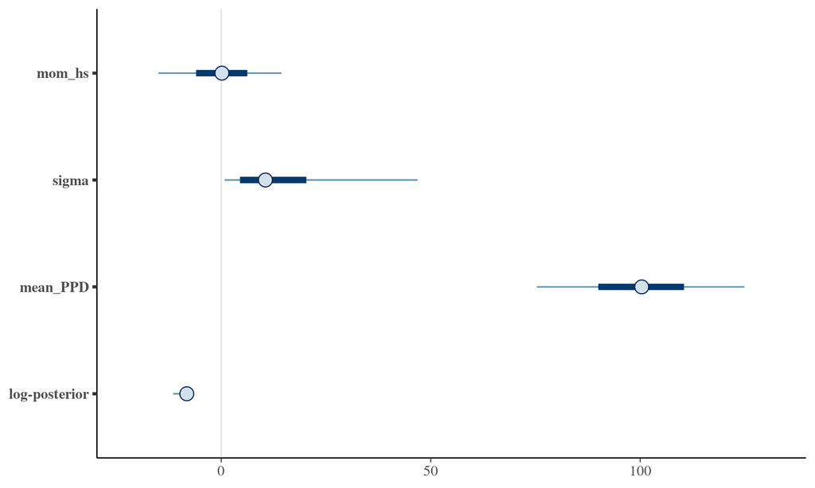

```r
prior_PD <- posterior_predict(priors)
dim(prior_PD); plot(priors, regex_pars = "^[^(Intercept)]") # exclude intercept
```

## Drawing from the Posterior Distribution

```r
post <- update(priors, prior_PD = FALSE)
```

```r
summary(post)
```

```
...
##                 mean    sd      2.5%    25%     50%     75%     97.5%
## (Intercept)      29.2     5.7    18.1    25.3    29.2    33.1    40.3
## mom_hs            5.6     2.1     1.4     4.2     5.6     7.1     9.7
## I(mom_iq/10)      5.3     0.6     4.2     4.9     5.3     5.7     6.5
## sigma            18.2     0.6    17.0    17.8    18.2    18.6    19.5
## mean_PPD         86.9     1.2    84.4    86.0    86.8    87.7    89.3
## log-posterior -1884.1     1.4 -1887.6 -1884.8 -1883.9 -1883.1 -1882.4
##
## Diagnostics:
##               mcse Rhat n_eff
## (Intercept)   0.1  1.0  4839
## mom_hs        0.0  1.0  4453
## I(mom_iq/10)  0.0  1.0  4843
## sigma         0.0  1.0  5221
## mean_PPD      0.0  1.0  4584
## log-posterior 0.0  1.0  1923
##
## For each parameter, mcse is Monte Carlo standard error, n_eff is a crude measure of effective sample size, and Rhat is the potential scale reduction factor on split chains (at convergence Rhat=1).
...
```

## Posterior vs. Prior

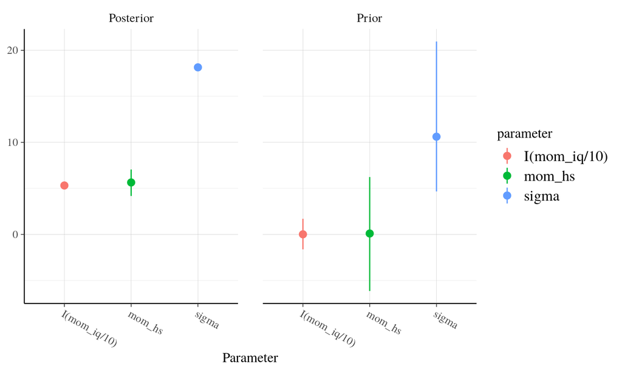

```r
posterior_vs_prior(post, prob = 0.5, regex_pars = "^[^(]") # excludes (Intercept)
```

## Plot at the Posterior Median Estimates

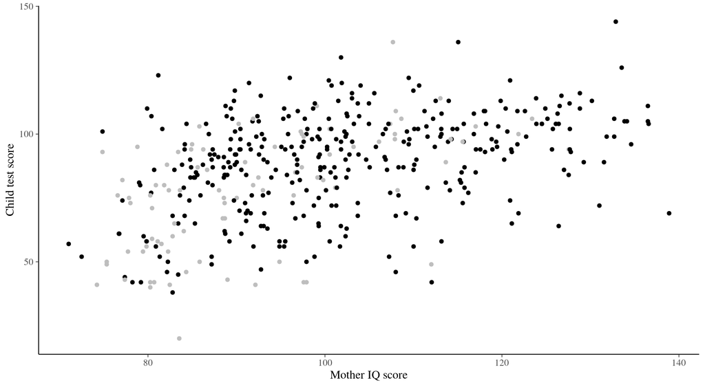

## Correct Plot

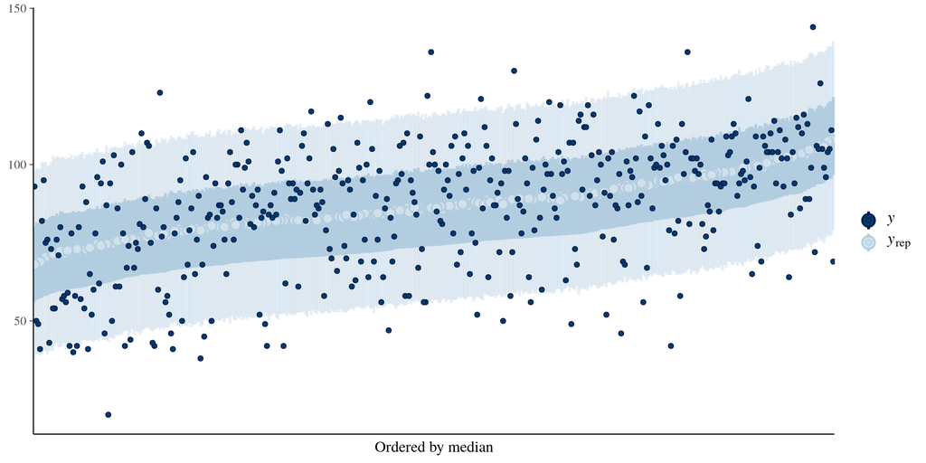

```r
pp_check(post, plotfun = "loo_intervals", order = "median")
```

## Utility Function for Predictions of Future Data

- For Bayesians, the log predictive PDF is the most appropriate utility function
- Choose the model that maximizes the expectation of this over FUTURE data \[\mbox{ELPD} = \mathbb{E}_Y \ln f\left(y_{N + 1}, y_{N + 2}, \dots, y_{2N} \mid y_1, y_2, \dots, y_N\right) = \\ \ln \int_{-\infty}^\infty \cdots \int_{-\infty}^\infty \int_{-\infty}^\infty f\left(y_{N + 1}, y_{N + 2}, \dots, y_{2N} \mid \mathbf{y}\right) dy_{N + 1} dy_{N + 2} \dots dy_{2N} \approx \\ \sum_{n = 1}^N \ln f\left(y_n \mid \mathbf{y}_{-n}\right) = \sum_{n = 1}^N \ln \int_\Theta f\left(y_n \mid \boldsymbol{\theta}\right) f\left(\boldsymbol{\theta} \mid \mathbf{y}_{-n}\right) d\theta_1 d\theta_2 \dots d\theta_K\]
- \(f\left(y_n \mid \boldsymbol{\theta}\right)\) is just the \(n\)-th likelihood contribution, but can we somehow obtain \(f\left(\boldsymbol{\theta} \mid \mathbf{y}_{-n}\right)\) from \(f\left(\boldsymbol{\theta} \mid \mathbf{y}\right)\)?
- Yes, assuming \(y_n\) does not have an outsized influence on the posterior

## Pareto Smoothed Importance Sampling

- Let \(r_n^s = \frac{1}{f\left(y_n \mid \widehat{\boldsymbol{\theta}}^s\right)} \propto \frac{f\left(\widehat{\boldsymbol{\theta}^s} \mid \mathbf{y}_{-n}\right)} {f\left(\widehat{\boldsymbol{\theta}^s} \mid \mathbf{y}\right)}\) be the \(s\)-th importance ratio for \(y_n\)
- Fit a generalized Pareto model to these importance ratios, which have PDF \[f\left(r_n \mid \mu, \sigma, k\right) = \frac{1}{\sigma}\left(1 + \frac{k\left(\mu - r_n\right)}{\sigma}\right)^{-1 - \frac{1}{k}}\]
- In the 20% right tail, use an interpolated \(\widehat{r}_n^s\) rather than \(r_n^s\)
- Doing so stabilizes the variances as long as the estimated shape parameters of the generalized Pareto distribution are not too large
  - \(\widehat{k}_n < 0.5\) is good and \(\widehat{k}_n \in \left[0.5, 0.7\right]\) is okay
  - \(\widehat{k}_n > 0.7\) is bad and \(\widehat{k}_n > 1.0\) is very bad

## PSISLOOCV with the Kid IQ Example

```r
loo(post)
```

```
##
## Computed from 4000 by 434 log-likelihood matrix
##
##          Estimate   SE
## elpd_loo  -1876.1 14.2
## p_loo         3.9  0.3
## looic      3752.2 28.5
## ------
## Monte Carlo SE of elpd_loo is 0.0.
##
## All Pareto k estimates are good (k < 0.5).
## See help('pareto-k-diagnostic') for details.
```

## Model with Interaction Term

```r
interaction <- update(post, formula. = . ~ . + mom_hs:mom_iq)
```

```r
compare_models(flat = loo(post), interaction = loo(interaction))
```

```
##
## Model comparison:
## (negative 'elpd_diff' favors 1st model, positive favors 2nd)
##
## elpd_diff        se
##       3.5       2.9
```

## Data on Diamonds

```r
data("diamonds", package = "ggplot2")
diamonds <- diamonds[diamonds$z > 0, ] # probably mistakes in the data
str(diamonds)
```

```
## Classes 'tbl_df', 'tbl' and 'data.frame':    53920 obs. of  10 variables:
##  $ carat  : num  0.23 0.21 0.23 0.29 0.31 0.24 0.24 0.26 0.22 0.23 ...
##  $ cut    : Ord.factor w/ 5 levels "Fair"<"Good"<..: 5 4 2 4 2 3 3 3 1 3 ...
##  $ color  : Ord.factor w/ 7 levels "D"<"E"<"F"<"G"<..: 2 2 2 6 7 7 6 5 2 5 ...
##  $ clarity: Ord.factor w/ 8 levels "I1"<"SI2"<"SI1"<..: 2 3 5 4 2 6 7 3 4 5 ...
##  $ depth  : num  61.5 59.8 56.9 62.4 63.3 62.8 62.3 61.9 65.1 59.4 ...
##  $ table  : num  55 61 65 58 58 57 57 55 61 61 ...
##  $ price  : int  326 326 327 334 335 336 336 337 337 338 ...
##  $ x      : num  3.95 3.89 4.05 4.2 4.34 3.94 3.95 4.07 3.87 4 ...
##  $ y      : num  3.98 3.84 4.07 4.23 4.35 3.96 3.98 4.11 3.78 4.05 ...
##  $ z      : num  2.43 2.31 2.31 2.63 2.75 2.48 2.47 2.53 2.49 2.39 ...
```

- What do you think is the prior \(R^2\) for a model of `log(price)`?

## Do This Once on Each Computer You Use

```r
cat('options(contrasts = c(unordered = "contr.treatment", ordered = "contr.treatment"))',
    file = "~/.Rprofile", sep = "\n", append = TRUE)
```

- Without this, you will get a weird rotation of the coefficients on the `cut` and `clarity` dummy variables
- `"contr.sum"` is another reasonable (but rare) choice

## The `stan_lm` Function

```r
post <- stan_lm(log(price) ~ carat * (log(x) + log(y) + log(z)) + cut + color + clarity,
                data = diamonds, prior = R2(location = 0.8, what = "mode"), adapt_delta = 0.9)
```

```r
str(as.data.frame(post), vec.len = 3, digits.d = 2)
```

```
## 'data.frame':    4000 obs. of  28 variables:
##  $ (Intercept)  : num  0.71 0.71 0.71 0.71 ...
##  $ carat        : num  7.3 7.5 7.3 7.4 ...
##  $ log(x)       : num  4.5 4.5 4.6 4.5 ...
##  $ log(y)       : num  -2.5 -2.4 -2.5 -2.4 ...
##  $ log(z)       : num  0.97 0.86 0.98 0.93 ...
##  $ cutGood      : num  0.083 0.086 0.09 0.079 ...
##  $ cutVery Good : num  0.12 0.13 0.13 0.12 ...
##  $ cutPremium   : num  0.13 0.14 0.14 0.13 ...
##  $ cutIdeal     : num  0.17 0.17 0.17 0.16 ...
##  $ colorE       : num  -0.054 -0.056 -0.052 -0.06 ...
##  $ colorF       : num  -0.093 -0.098 -0.092 -0.103 ...
##  $ colorG       : num  -0.16 -0.17 -0.16 -0.17 ...
##  $ colorH       : num  -0.26 -0.26 -0.25 -0.26 ...
##  $ colorI       : num  -0.37 -0.38 -0.37 -0.38 ...
##  $ colorJ       : num  -0.51 -0.51 -0.51 -0.52 ...
##  $ claritySI2   : num  0.42 0.42 0.41 0.42 ...
##  $ claritySI1   : num  0.58 0.59 0.58 0.59 ...
##  $ clarityVS2   : num  0.73 0.73 0.73 0.73 ...
##  $ clarityVS1   : num  0.8 0.8 0.8 0.81 ...
##  $ clarityVVS2  : num  0.93 0.94 0.93 0.93 ...
##  $ clarityVVS1  : num  1 1 1 1 ...
##  $ clarityIF    : num  1.1 1.1 1.1 1.1 ...
##  $ carat:log(x) : num  -3.9 -4 -3.9 -3.9 ...
##  $ carat:log(y) : num  1.9 1.9 1.9 1.8 ...
##  $ carat:log(z) : num  -1.1 -1 -1.1 -1 ...
##  $ sigma        : num  0.13 0.13 0.13 0.13 ...
##  $ log-fit_ratio: num  -0.00102 0.00107 -0.00123 -0.00015 ...
##  $ R2           : num  0.98 0.98 0.98 0.98 ...
```

## Typical Output

```r
print(post, digits = 4)
```

[output not shown]

## What Is the Effect of an Increase in Carat?

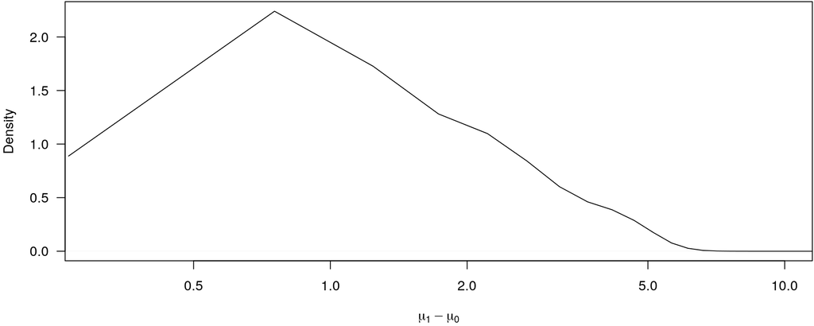

```r
mu_0 <- exp(posterior_linpred(post, draws = 500)) / 1000
df <- diamonds[diamonds$z > 0, ]; df$carat <- df$carat + 0.2
mu_1 <- exp(posterior_linpred(post, newdata = df, draws = 500)) / 1000
plot(density(mu_1 - mu_0), xlab = expression(mu[1] - mu[0]), xlim = c(.3, 10), log = "x", main = "")
```

## But Wait

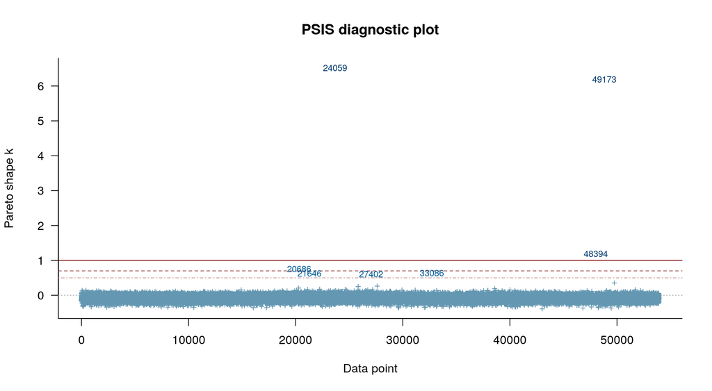

```r
plot(loo(post), label_points = TRUE)
```